# Top 10 Longest and Shortest Lived Presidents

Michael Bentz

2022-05-16

To maintain data integrity, currently living presidents have been excluded in the following report. This report showcases the top 10 longest lived presidents, and the top 10 shortest lived presidents, measured in days. The 1800s has the highest concentration of shortest lived presidents and the 1700 and 1900s have the highest concentration of longest lived presidents. These findings are demonstrated in Figure 3.

## Top 10

Table 1: Top 10 presidents from longest lived to shortest lived

| president | birth_date | birth_place | death_date | location_of_death | year_of_birth | lived_years | lived_months | lived_days |
| --- | --- | --- | --- | --- | --- | --- | --- | --- |
| George Bush | 1924-06-12 | Milton, Mass. | 2018-11-30 | Houston, Texas | 1924 | 94 | 1133 | 34504 |
| Gerald Ford | 1913-07-14 | Omaha, Nebraska | 2006-12-26 | Rancho Mirage, Cal. | 1913 | 93 | 1121 | 34133 |
| Ronald Reagan | 1911-02-06 | Tampico, Illinois | 2004-06-05 | Los Angeles, Cal. | 1911 | 93 | 1119 | 34088 |
| John Adams | 1735-10-30 | Quincy, Mass. | 1826-07-04 | Quincy, Mass. | 1735 | 90 | 1088 | 33119 |
| Herbert Hoover | 1874-08-10 | West Branch, Iowa | 1964-10-20 | New York, New York | 1874 | 90 | 1082 | 32943 |
| Harry S. Truman | 1884-05-08 | Lamar, Missouri | 1972-12-26 | Kansas City, Missouri | 1884 | 88 | 1063 | 32373 |
| James Madison | 1751-03-16 | Port Conway, Va. | 1836-06-28 | Orange Co., Va. | 1751 | 85 | 1023 | 31150 |
| Thomas Jefferson | 1743-04-13 | Albemarle Co., Va. | 1826-07-04 | Albemarle Co., Va. | 1743 | 83 | 998 | 30397 |
| Richard Nixon | 1913-01-09 | Yorba Linda, Cal. | 1994-04-22 | New York, New York | 1913 | 81 | 975 | 29688 |
| John Quincy Adams | 1767-07-11 | Quincy, Mass. | 1848-02-23 | Washington, D.C. | 1767 | 80 | 967 | 29446 |

Table 2: Top 10 presidents from shortest lived to longest lived

| president | birth_date | birth_place | death_date | location_of_death | year_of_birth | lived_years | lived_months | lived_days |
| --- | --- | --- | --- | --- | --- | --- | --- | --- |
| John F. Kennedy | 1917-05-29 | Brookline, Mass. | 1963-11-22 | Dallas, Texas | 1917 | 46 | 557 | 16978 |
| James A. Garfield | 1831-11-19 | Cuyahoga Co., Ohio | 1881-09-19 | Elberon, New Jersey | 1831 | 49 | 598 | 18202 |
| James K. Polk | 1795-11-02 | Mecklenburg Co., N.C. | 1849-06-15 | Nashville, Tennessee | 1795 | 53 | 643 | 19583 |
| Abraham Lincoln | 1809-02-12 | LaRue Co., Kentucky | 1865-04-15 | Washington, D.C. | 1809 | 56 | 674 | 20516 |
| Chester Arthur | 1829-10-05 | Fairfield, Vermont | 1886-11-18 | New York, New York | 1829 | 57 | 685 | 20863 |
| Warren G. Harding | 1865-11-02 | Morrow County, Ohio | 1923-08-02 | San Francisco, Cal. | 1865 | 57 | 693 | 21091 |
| William McKinley | 1843-01-29 | Niles, Ohio | 1901-09-14 | Buffalo, New York | 1843 | 58 | 703 | 21412 |
| Theodore Roosevelt | 1858-10-27 | New York, New York | 1919-01-06 | Oyster Bay, New York | 1858 | 60 | 722 | 21985 |
| Calvin Coolidge | 1872-07-04 | Plymouth, Vermont | 1933-01-05 | Northampton, Mass. | 1872 | 60 | 726 | 22099 |
| Franklin Roosevelt | 1882-01-30 | Hyde Park, New York | 1945-04-12 | Warm Springs, Ga. | 1882 | 63 | 758 | 23082 |

## Analysis

The birth year was rounded down to reduce noise. Rounding down to the nearest 50 year interval struck the best balance between data point volume and visual clarity. At first glance, the left plot of Figure 3 might give the impression that shortest lived presidents are almost evenly distributed from 1750 to 1900. However, looking more closely we notice that both have a standard deviation of 0 because only a single entry exists. This is verified by the plot to the right.

Table 3: The frequency, mean, median, max, min, standard deviation, mode, and weighted mean of the top 10 longest and shortest days lived

| year_of_birth | label | frequency | mean | median | max | min | standard_deviation | mode | weighted_mean |
| --- | --- | --- | --- | --- | --- | --- | --- | --- | --- |
| 1700 | longest_lived | 2 | 31758.00 | 31758.0 | 33119 | 30397 | 641.5816 | NA | 25670.50 |
| 1750 | longest_lived | 2 | 30298.00 | 30298.0 | 31150 | 29446 | 401.6367 | NA | 25273.12 |
| 1850 | longest_lived | 2 | 32658.00 | 32658.0 | 32943 | 32373 | 134.3503 | NA | 27361.12 |
| 1900 | longest_lived | 4 | 33103.25 | 34110.5 | 34504 | 29688 | 1318.9285 | NA | 25040.62 |
| 1750 | shortest_lived | 1 | 19583.00 | 19583.0 | 19583 | 19583 | 0.0000 | NA | 25670.50 |
| 1800 | shortest_lived | 4 | 20248.25 | 20689.5 | 21412 | 18202 | 815.8881 | NA | 25273.12 |
| 1850 | shortest_lived | 4 | 22064.25 | 22042.0 | 23082 | 21091 | 470.2858 | NA | 27361.12 |
| 1900 | shortest_lived | 1 | 16978.00 | 16978.0 | 16978 | 16978 | 0.0000 | NA | 25040.62 |

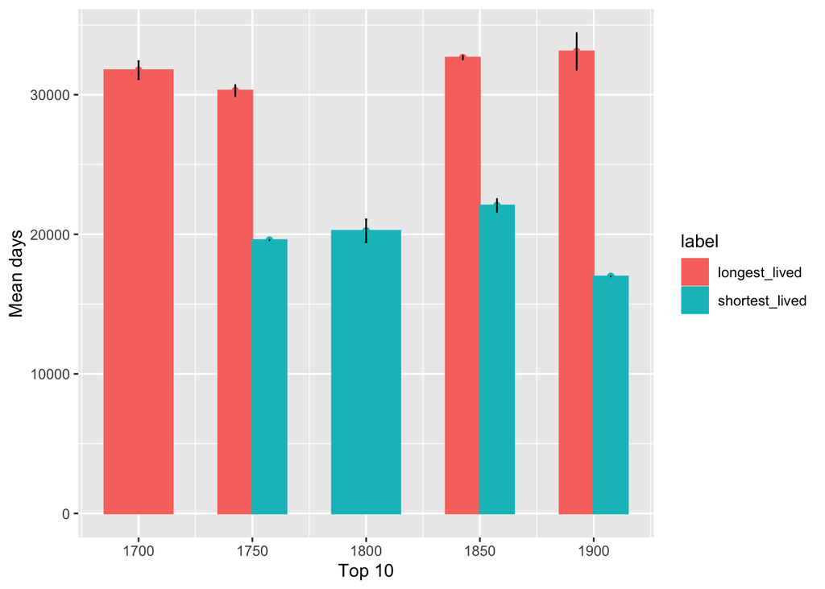

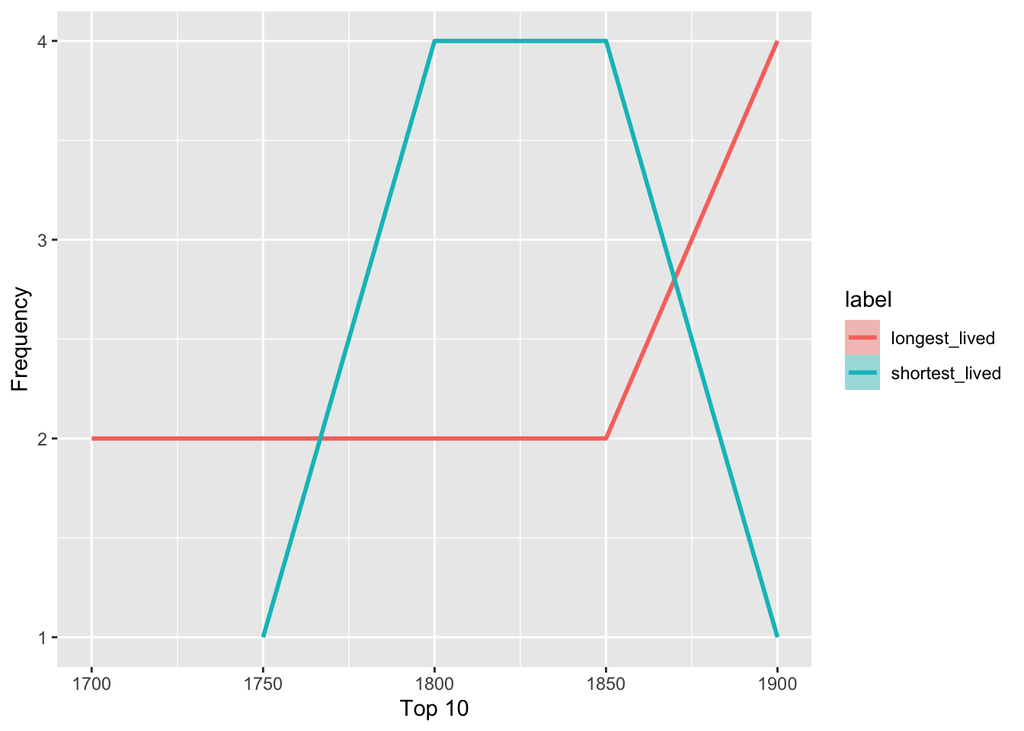

Figure 3: Top 10 longest and shortest lived presidents rounded down to the nearest 50 year interval. The concentration of longest lived days is highest during the 1701 and 1900’s, whereas the concentration of shortest lived days is highest during the 1801’s.

### Conclusion

We can clearly see that there is a correlation between presidents born in the 1800’s and being listed in the top 10 shortest lived. 80% (8 out of 10) of presidents that are in the 10 top shortest lived were born during the 1800’s. Also, 80% of presidents born in the 1700 and 1900s are listed in the top 10 longest lived.